# Exploratory Data Analysis of Used Vehicle Prices

## Overview

This analysis examines how used vehicle prices are influenced by key factors such as age, mileage, and manufacturer.  
To better understand pricing patterns, normalized metrics such as price per year and price per mile are used to evaluate how value varies across listings.

## Dataset

- Source: Kaggle used car listings dataset
- Size: 357,927 rows (after cleaning)
- Key columns:
  - price
  - year
  - odometer (mileage)
  - manufacturer
  - model

## Import Statements and Data Overview

```python
import numpy as np
import pandas as pd
import matplotlib.pyplot as plt
import seaborn as sns
sns.set_style("white")

df = pd.read_csv("vehicles_analysis.csv")

df.head()
```

|  | id | region | price | year | manufacturer | model | condition | cylinders | fuel | odometer | ... | transmission | VIN | drive | size | type | paint_color | state | latitude | longitude | posting_date |
| --- | --- | --- | --- | --- | --- | --- | --- | --- | --- | --- | --- | --- | --- | --- | --- | --- | --- | --- | --- | --- | --- |
| 0 | 7316814884 | auburn | 33590 | 2014 | gmc | sierra 1500 crew cab slt | good | 8 cylinders | gas | 57923 | ... | other | 3GTP1VEC4EG551563 | NaN | NaN | pickup | white | al | 32.590000 | -85.480003 | 2021-05-04 13:31:18.000 |
| 1 | 7316814758 | auburn | 22590 | 2010 | chevrolet | silverado 1500 | good | 8 cylinders | gas | 71229 | ... | other | 1GCSCSE06AZ123805 | NaN | NaN | pickup | blue | al | 32.590000 | -85.480003 | 2021-05-04 13:31:08.000 |
| 2 | 7316814989 | auburn | 39590 | 2020 | chevrolet | silverado 1500 crew | good | 8 cylinders | gas | 19160 | ... | other | 3GCPWCED5LG130317 | NaN | NaN | pickup | red | al | 32.590000 | -85.480003 | 2021-05-04 13:31:25.000 |
| 3 | 7316743432 | auburn | 30990 | 2017 | toyota | tundra double cab sr | good | 8 cylinders | gas | 41124 | ... | other | 5TFRM5F17HX120972 | NaN | NaN | pickup | red | al | 32.590000 | -85.480003 | 2021-05-04 11:41:31.000 |
| 4 | 7316356412 | auburn | 15000 | 2013 | ford | f-150 xlt | excellent | 6 cylinders | gas | 128000 | ... | automatic | NaN | rwd | full-size | truck | black | al | 32.591999 | -85.518898 | 2021-05-03 15:02:03.000 |

5 rows × 21 columns

```python
df.info()
```

```
<class 'pandas.DataFrame'>
RangeIndex: 357927 entries, 0 to 357926
Data columns (total 21 columns):
 #   Column        Non-Null Count   Dtype
---  ------        --------------   -----
 0   id            357927 non-null  int64
 1   region        357927 non-null  str
 2   price         357927 non-null  int64
 3   year          357927 non-null  int64
 4   manufacturer  347371 non-null  str
 5   model         354081 non-null  str
 6   condition     219351 non-null  str
 7   cylinders     210354 non-null  str
 8   fuel          355901 non-null  str
 9   odometer      357927 non-null  int64
 10  title_status  351308 non-null  str
 11  transmission  356490 non-null  str
 12  VIN           230657 non-null  str
 13  drive         250097 non-null  str
 14  size          97257 non-null   str
 15  type          285258 non-null  str
 16  paint_color   254162 non-null  str
 17  state         357927 non-null  str
 18  latitude      354708 non-null  float64
 19  longitude     354689 non-null  float64
 20  posting_date  357927 non-null  str
dtypes: float64(2), int64(4), str(15)
memory usage: 57.3 MB
```

```python
df[["price", "odometer", "year"]].describe().T
```

|  | count | mean | std | min | 25% | 50% | 75% | max |
| --- | --- | --- | --- | --- | --- | --- | --- | --- |
| price | 357927.0 | 19456.745174 | 15113.138261 | 100.0 | 7980.0 | 15995.0 | 27995.0 | 470000.0 |
| odometer | 357927.0 | 92318.221087 | 61813.614939 | 100.0 | 39029.0 | 87061.0 | 134397.5 | 400000.0 |
| year | 357927.0 | 2012.838294 | 5.033048 | 2000.0 | 2009.0 | 2014.0 | 2017.0 | 2022.0 |

## Data Cleaning

Data cleaning was performed in SQL prior to analysis to transform the raw Craigslist vehicle listings into a structured, analysis-ready dataset. The goal of this process was to improve data quality, remove invalid entries, and ensure consistency across key variables such as price, mileage, and vehicle attributes.  
This process follows a typical ETL (Extract, Transform, Load) workflow used in data analytics pipelines.

### 1. Data Structuring & Standardization

Several structural changes were made to improve consistency and usability of the dataset.

- Removed non-analytical columns such as URLs and vehicle description text fields
- Standardized column names for clarity (e.g., lat → latitude, long → longitude)
- Organized cleaned data into a structured table for downstream analysis

### 2. Data Quality Cleaning (Missing & Invalid Values)

Invalid or non-informative values were handled to improve data reliability.

- Removed or nullified malformed model entries (e.g., extremely short or non-alphanumeric strings)
- Ensured consistent formatting of categorical variables such as manufacturer and model

### 3. Analysis-Ready Filtering (Outliers & Constraints)

To ensure the dataset reflects realistic used car market behavior, extreme values and outliers were removed.

- Filtered vehicles to model year ≥ 2000 to focus on modern vehicles
- Removed listings with mileage < 100 miles (likely data entry errors or near-new listings)
- Restricted mileage values to a realistic range (100–400,000 miles)
- Removed extreme price outliers (e.g., invalid or excessively high values)

### Final Dataset Preparation

After cleaning, the processed data was stored in a dedicated analysis view (vehicles_analysis) to separate raw data from the final dataset used in Python analysis.  
Full SQL logic is available in `vehicles_ETL_cleaning.sql` and `vehicles_analysis_view.sql` within the repository for reproducibility.

## Feature Engineering

To enhance the analysis, two derived features were created to normalize price relative to vehicle age and usage. These features help capture value efficiency across different vehicles by accounting for differences in model year and mileage.

```python
df["price_per_year"] = df["price"] / df["year"].replace(0, np.nan)
df["price_per_mile"] = df["price"] / df["odometer"].replace(0, np.nan)

df[["price", "odometer", "year", "price_per_year", "price_per_mile"]].describe().T
```

|  | count | mean | std | min | 25% | 50% | 75% | max |
| --- | --- | --- | --- | --- | --- | --- | --- | --- |
| price | 357927.0 | 19456.745174 | 15113.138261 | 100.000000 | 7980.000000 | 15995.000000 | 27995.000000 | 470000.000000 |
| odometer | 357927.0 | 92318.221087 | 61813.614939 | 100.000000 | 39029.000000 | 87061.000000 | 134397.500000 | 400000.000000 |
| year | 357927.0 | 2012.838294 | 5.033048 | 2000.000000 | 2009.000000 | 2014.000000 | 2017.000000 | 2022.000000 |
| price_per_year | 357927.0 | 9.655722 | 7.488769 | 0.049480 | 3.965774 | 7.943368 | 13.897716 | 233.134921 |
| price_per_mile | 357927.0 | 1.583910 | 13.941959 | 0.000365 | 0.062409 | 0.185827 | 0.671716 | 1421.352201 |

## Exploratory Data Analysis (EDA)

This section explores relationships between price, mileage, vehicle age, and manufacturer to identify key market patterns.

### Price Relationships

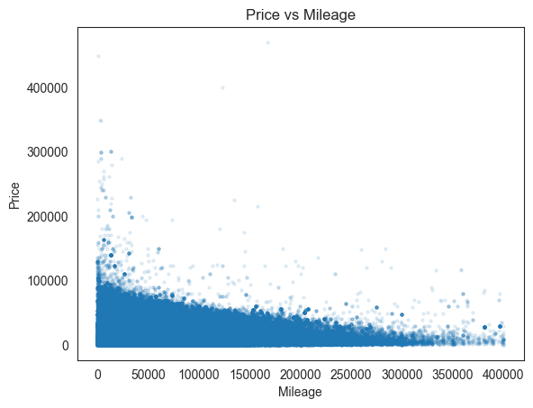

```python
plt.scatter(df["odometer"], df["price"], alpha=0.1, s=5)

plt.title("Price vs Mileage")
plt.xlabel("Mileage")
plt.ylabel("Price")
```

The full dataset includes several extreme outliers that compress the visualization. A second plot focuses on the typical range to better highlight the relationship between price and mileage.

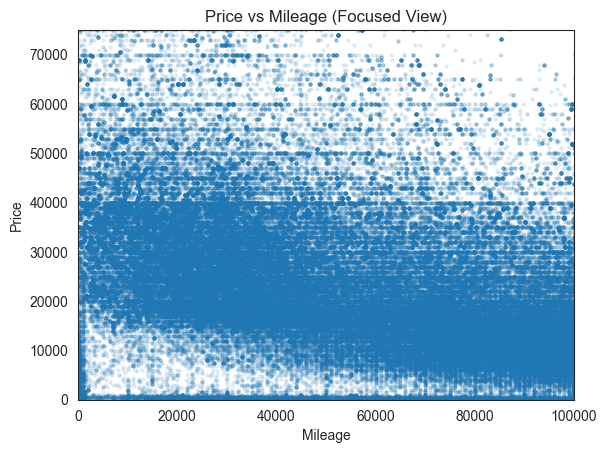

```python
plt.scatter(df["odometer"], df["price"], alpha=0.1, s=5)

plt.xlim(0, 100000)
plt.ylim(0, 75000)

plt.title("Price vs Mileage (Focused View)")
plt.xlabel("Mileage")
plt.ylabel("Price")
```

Vehicle price shows a clear negative relationship with mileage, with prices generally decreasing as mileage increases.  
Price variability is highest among low-mileage vehicles, where listings range widely in price.

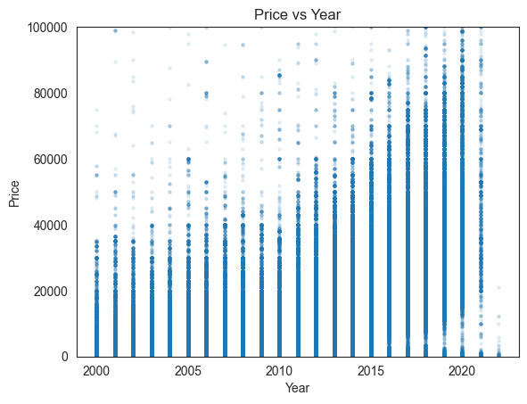

```python
plt.scatter(df["year"], df["price"], alpha=0.1, s=5)

plt.ylim(0, 100000)

plt.title("Price vs Year")
plt.xlabel("Year")
plt.ylabel("Price")
```

There is a clear positive relationship between model year and price, where newer vehicles tend to command higher prices.  
This reflects standard vehicle depreciation patterns, where older cars lose value over time.

### Distribution Analysis

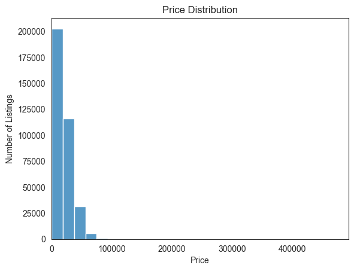

```python
sns.histplot(df['price'], bins=25)

plt.xlim(left = 0)

plt.title("Price Distribution")
plt.xlabel("Price")
plt.ylabel("Number of Listings")
```

The price distribution is heavily right-skewed, with most vehicles concentrated in the lower price range and a long tail extending into higher-end values.  
A second plot focuses on the typical range to better highlight the relationship between price and number of listings.

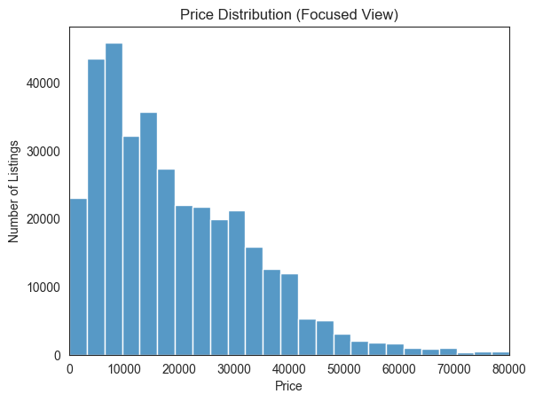

```python
sns.histplot(df['price'], binrange = (0, 80000), bins=25)

plt.xlim(0, 80000)

plt.title("Price Distribution (Focused View)")
plt.xlabel("Price")
plt.ylabel("Number of Listings")
```

When focusing on vehicles priced below `$80,000`, the distribution becomes significantly clearer, revealing a strong concentration of listings in the `$5,000–$35,000` range.  
The distribution still shows right-skewness, but with a more interpretable shape that better represents typical consumer purchasing behavior.

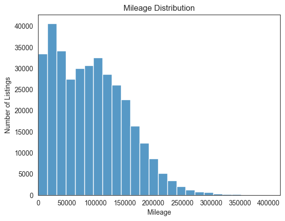

```python
sns.histplot(df['odometer'], bins=25)

plt.xlim(left = 0)

plt.title("Mileage Distribution")
plt.xlabel("Mileage")
plt.ylabel("Number of Listings")
```

The mileage distribution is right-skewed, with most vehicles concentrated in the lower mileage range and a long tail extending toward high-mileage vehicles.  
Interestingly, there is a slight dip around ~50,000 miles, which may reflect market behavior where vehicles are more commonly sold at milestone intervals such as lease returns (~30–40k miles) or before major maintenance thresholds (~60k+ miles)

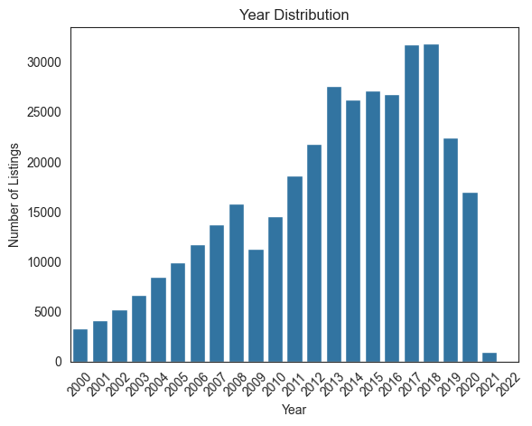

```python
sns.countplot(x='year', data=df)
plt.xticks(rotation=45)

plt.title("Year Distribution")
plt.xlabel("Year")
plt.ylabel("Number of Listings")
```

The year distribution is left-skewed, with most vehicles concentrated in more recent model years. A clear peak appears around 2017–2018, which is consistent with typical used car market behavior where vehicles around 3–5 years old are most commonly traded.  
Given that the dataset is from 2021, this peak likely represents cars that are off-lease or have reached a balance between depreciation and remaining value.

### Mileage vs Year Interaction

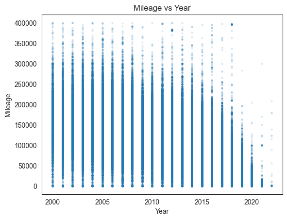

```python
plt.scatter(df["year"], df["odometer"], alpha = 0.1, s = 5)

plt.title("Mileage vs Year")
plt.xlabel("Year")
plt.ylabel("Mileage")
```

Mileage and model year show an overall negative relationship, with newer vehicles generally having lower mileage. From 2000 to around 2010, mileage appears relatively stable, suggesting a mix of older vehicles with varying usage histories.  
After 2010, mileage decreases more noticeably, which may reflect the increased presence of newer, less-used vehicles in the dataset as well as shorter ownership cycles in more recent years.  
This pattern is likely influenced by both market composition and survival bias in older vehicles.

### Manufacturer Analysis

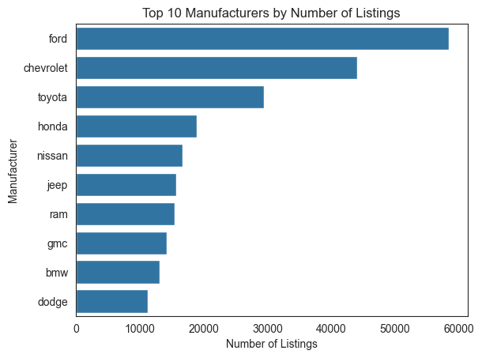

```python
top10 = df['manufacturer'].value_counts().nlargest(10).index

sns.countplot(
    y='manufacturer',
    data=df[df['manufacturer'].isin(top10)],
    order=top10
)

plt.title("Top 10 Manufacturers by Number of Listings")
plt.xlabel("Number of Listings")
plt.ylabel("Manufacturer")
```

The distribution is heavily dominated by domestic U.S. manufacturers, suggesting the dataset reflects a U.S.-centric used car market.  
Toyota and Honda rank highly, consistent with their reputation for reliability and strong resale activity in the used car market.  
The presence of multiple truck and SUV manufacturers among the top listings suggests a strong bias toward utility and larger vehicles in the dataset.  
BMW appears in the top 10 despite being a luxury manufacturer, indicating strong secondary-market activity for entry-level luxury vehicles.

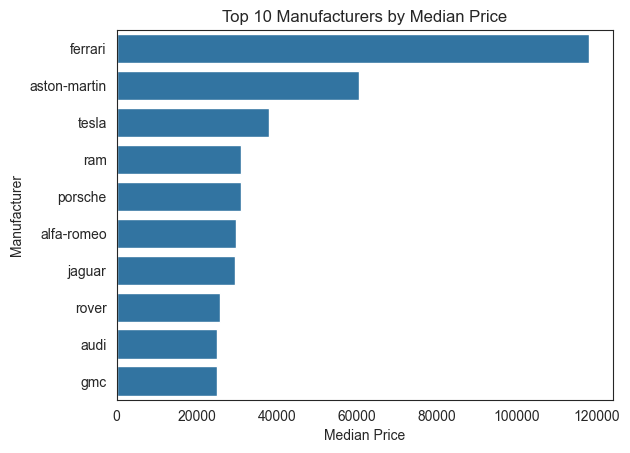

```python
top10 = df.groupby('manufacturer')['price'].median().nlargest(10)

sns.barplot(
    x=top10.values,
    y=top10.index,
)

plt.title("Top 10 Manufacturers by Median Price")
plt.xlabel("Median Price")
plt.ylabel("Manufacturer")
```

The highest median prices are dominated by luxury and performance-oriented manufacturers, which is consistent with expected market pricing structures.  
Tesla’s presence among the highest median-priced manufacturers reflects strong residual demand and relatively slow depreciation compared to many traditional brands.  
High-end trims of pickup trucks and SUVs can reach price levels comparable to entry-level luxury vehicles, indicating strong pricing overlap between utility and luxury segments.

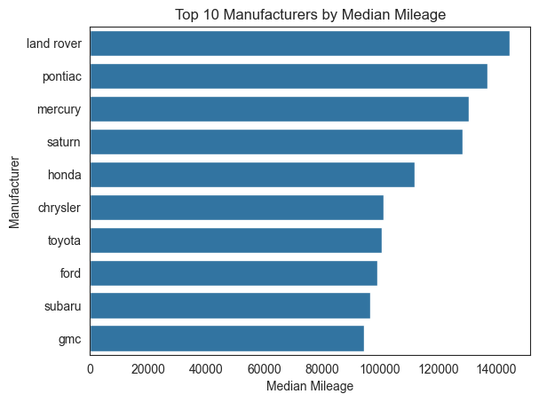

```python
top10 = df.groupby('manufacturer')['odometer'].median().nlargest(10)

sns.barplot(
    x=top10.values,
    y=top10.index,
)

plt.title("Top 10 Manufacturers by Median Mileage")
plt.xlabel("Median Mileage")
plt.ylabel("Manufacturer")
```

The top manufacturers by median mileage include a mix of legacy brands such as Pontiac, Mercury, and Saturn, alongside modern mass-market brands like Honda, Toyota, and Ford.  
The presence of discontinued brands at the top is likely driven by survivorship bias, where only higher-mileage vehicles remain in circulation and appear in the dataset

## Limitations

This analysis is based on a dataset of vehicle listings scraped from Craigslist over a limited period in 2021 and may not reflect broader market trends or seasonal variation. As the data is sourced from a single platform, it may be biased toward private sellers and lower-priced vehicles, limiting its representation of the overall used car market.  
Some listings may contain missing, inaccurate, or inconsistently formatted data, which can affect the reliability of certain analyses.  
Key variables such as vehicle condition, accident history, and trim level are not fully captured, which limits the ability to fully explain price differences across listings.

## Conclusion

This analysis explored pricing, mileage, and manufacturer trends within a Craigslist-based used car dataset from 2021. The results show that the market is largely concentrated in mid-priced vehicles, with price strongly influenced by both vehicle age and mileage. Manufacturer differences highlight clear segmentation, with luxury brands commanding higher prices and mass-market brands driving listing volume. These findings reflect typical used car market dynamics, including depreciation and the impact of brand and vehicle type on pricing. While the dataset has limitations, such as platform bias and missing variables, it provides a realistic snapshot of resale market behavior. Future analysis could incorporate additional data sources or features such as vehicle condition and trim level to improve predictive accuracy.